# Correlation Test Between Two Variables

### 1. What is correlation test?

- Correlation test is used to evaluate the association between two or more variables.
- For instance, if we are interested to know whether there is a relationship between the heights of fathers and sons, a correlation coefficient can be calculated to answer this question.
- If there is no relationship between the two variables (father and son heights), the average height of son should be the same regardless of the height of the fathers and vice versa.

### 2. Install and load required R packages

- We’ll use the `{ggpubr}` R package for an easy ggplot2-based data visualization

```r
# install.packages("ggpubr", dependencies = TRUE)
library("ggpubr")
```

### 3. Methods for correlation analyses

- There are different methods to perform correlation analysis:
  - **Pearson correlation (r)**,
    - which measures a linear dependence between two variables (x and y).
    - It’s also known as a parametric correlation test because it depends to the distribution of the data.
    - It can be used only when x and y are from normal distribution.
    - The plot of **y = f(x)** is named the linear regression curve.
  - **Kendall tau** and **Spearman rho**, which are rank-based correlation coefficients (non-parametric)
- The most commonly used method is the **Pearson** correlation method.

### 4. Correlation formula

- In the formula below,
  - `x` and `y` are two vectors of length `n`
  - m<sub>x</sub> and m<sub>y</sub> corresponds to the means of `x` and `y`, respectively.

### 5. Pearson correlation formula

$r=\frac{\sum{(x - m_x)(y - m_y)}}{\sqrt{\sum{(x - m_x)^{2}}\sum{(y - m_y)^{2}}}}$

- m<sub>x</sub> and m<sub>y</sub> are the means of x and y variables.
- The p-value (significance level) of the correlation can be determined :
  - by using the correlation coefficient table for the degrees of freedom : `df = n − 2` where n is the number of observation in x and y variables.
  - or by calculating the t value as follow:

$t = \frac{r}{\sqrt{1 - r^{2}}}\sqrt{n - 2}$

- In the above case, the corresponding p-value is determined using t distribution table for `df = n − 2`
- If the p-value is < 5%, then the correlation between x and y is significant.

### 6. Spearman correlation formula

- The Spearman correlation method computes the correlation between the rank of x and the rank of y variables.

$rho = \frac{\sum{(x' - m_x')(y'_i - m_y'))}}{\sqrt{\sum{(x' - m_x')^{2}}\sum{(y' - m_y')^2}}}$

- Where, `x′ = rank(x)` and `y′ = rank(y)`

### 7. Kendall correlation formula

- The Kendall correlation method measures the correspondence between the ranking of x and y variables.
- The total number of possible pairings of x with y observations is `n(n−1)/2`, where `n` is the size of `x` and `y`.
- The procedure is as follow:
  - Begin by ordering the pairs by the x values. If x and y are correlated, then they would have the same relative rank orders.
  - Now, for each yi, count the number of y<sub>j</sub> > y<sub>i</sub> (concordant pairs (c)) and the number of y<sub>j</sub> < y<sub>i</sub> (discordant pairs (d)).
- **Kendall correlation distance** is defined as follow:

  $tau = \frac{n_c - n_d}{\frac{1}{2}n(n-1)}$
  - Where,
    - `nc`: total number of concordant pairs
    - `nd`: total number of discordant pairs
    - `n` : size of x and y

### 8. Compute correlation in R

- R functions:  
  Correlation coefficient can be computed using the functions `cor{stats}` or `cor.test{stats}`:
  - `cor{stats}` computes the correlation coefficient
  - `cor.test{stats}` test for association/correlation between paired samples.
- It returns both the correlation coefficient and the significance level(or p-value) of the correlation.
- The simplified formats are:

```r
cor(x, y, method = c("pearson", "kendall", "spearman"))
cor.test(x, y, method=c("pearson", "kendall", "spearman"))

# x, y: numeric vectors with the same length
# method: correlation method
```

- If your data contain missing values, use the following R code to handle missing values by case-wise deletion: `cor(x, y, method = "pearson", use = "complete.obs")`

### 9. Import your data into R

- Here, we’ll use the built-in R data set `mtcars{datasets}` as an example.
- The R code below computes the correlation between `mpg` and `wt` variables in `mtcars{datasets}`:
- We want to compute the correlation between `mpg` and `wt` variables.

```r
library(dplyr)
library(knitr)

my_data <- mtcars

kable( sample_n(my_data, 10, F) )
```

|  | mpg | cyl | disp | hp | drat | wt | qsec | vs | am | gear | carb |
| --- | --- | --- | --- | --- | --- | --- | --- | --- | --- | --- | --- |
| Lincoln Continental | 10.4 | 8 | 460.0 | 215 | 3.00 | 5.424 | 17.82 | 0 | 0 | 3 | 4 |
| Merc 450SE | 16.4 | 8 | 275.8 | 180 | 3.07 | 4.070 | 17.40 | 0 | 0 | 3 | 3 |
| Cadillac Fleetwood | 10.4 | 8 | 472.0 | 205 | 2.93 | 5.250 | 17.98 | 0 | 0 | 3 | 4 |
| Toyota Corona | 21.5 | 4 | 120.1 | 97 | 3.70 | 2.465 | 20.01 | 1 | 0 | 3 | 1 |
| Valiant | 18.1 | 6 | 225.0 | 105 | 2.76 | 3.460 | 20.22 | 1 | 0 | 3 | 1 |
| Mazda RX4 Wag | 21.0 | 6 | 160.0 | 110 | 3.90 | 2.875 | 17.02 | 0 | 1 | 4 | 4 |
| Merc 450SLC | 15.2 | 8 | 275.8 | 180 | 3.07 | 3.780 | 18.00 | 0 | 0 | 3 | 3 |
| Merc 450SL | 17.3 | 8 | 275.8 | 180 | 3.07 | 3.730 | 17.60 | 0 | 0 | 3 | 3 |
| Duster 360 | 14.3 | 8 | 360.0 | 245 | 3.21 | 3.570 | 15.84 | 0 | 0 | 3 | 4 |
| Hornet 4 Drive | 21.4 | 6 | 258.0 | 110 | 3.08 | 3.215 | 19.44 | 1 | 0 | 3 | 1 |

### 10. Visualize your data using scatter plots

- To use R base graphs:
  - Here, we’ll use the `{ggpubr}` R package for `scatter plot`

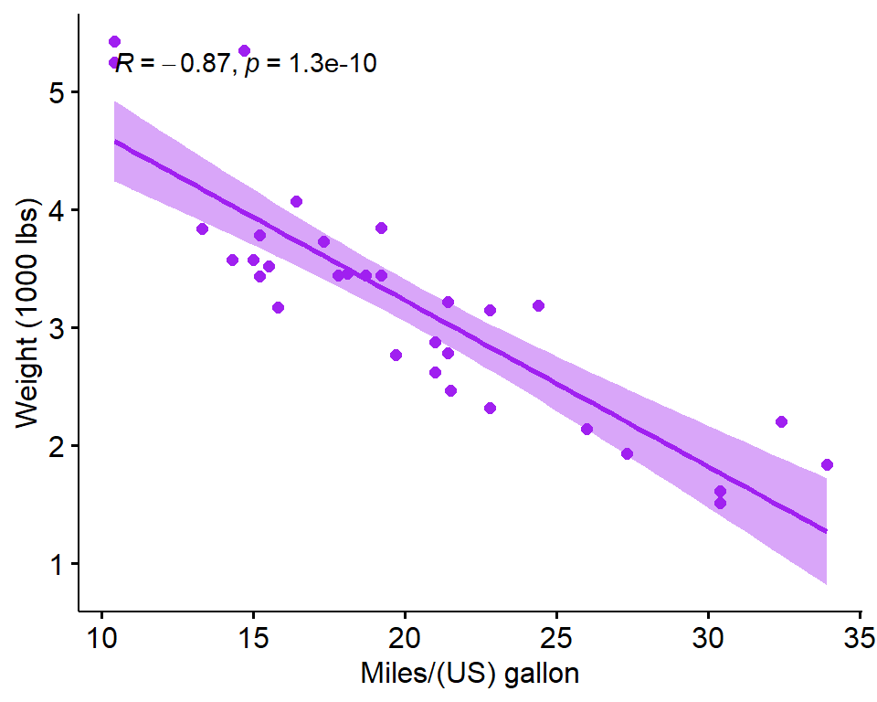

```r
library("ggpubr")

ggscatter(my_data,
          col = 'purple',
          x = "mpg",
          y = "wt",
          add = "reg.line",
          conf.int = TRUE,
          cor.coef = TRUE,
          cor.method = "pearson",
          xlab = "Miles/(US) gallon",
          ylab = "Weight (1000 lbs)")
```

### 11. Preleminary test to check the test assumptions

- Is the `covariation linear` ?
  - Yes, from the plot above, the relationship is linear.
  - In the situation where the scatter plots show curved patterns, we are dealing with nonlinear association between the two variables.
- Are the data from each of the 2 variables (`x`, `y`) follow a `normal` distribution ?
  - Use `Shapiro-Wilk normality test` through the R function: `shapiro.test{stats}`
  - look at the normality plot through the R function: `ggqqplot{ggpubr}`
- `Shapiro-Wilk test` can be performed as follow:
  - H<sub>0</sub>: the data are normally distributed.
  - H<sub>1</sub>: the data are not normally distributed.

```r
# Shapiro-Wilk normality test for mpg
shapiro.test(my_data$mpg) # => p = 0.1229
```

```
##
##  Shapiro-Wilk normality test
##
## data:  my_data$mpg
## W = 0.94756, p-value = 0.1229
```

```r
# Shapiro-Wilk normality test for wt
shapiro.test(my_data$wt) # => p = 0.09
```

```
##
##  Shapiro-Wilk normality test
##
## data:  my_data$wt
## W = 0.94326, p-value = 0.09265
```

- From the output, the two `p-values` are greater than the significance level 0.05 implying that the distribution of the data are not significantly different from normal distribution. In other words, we can assume the normality.
- Visual inspection of the data normality using `Q-Q plots` (`quantile-quantile plots`).  
  `Q-Q plot` draws the correlation between a given sample and the normal distribution.

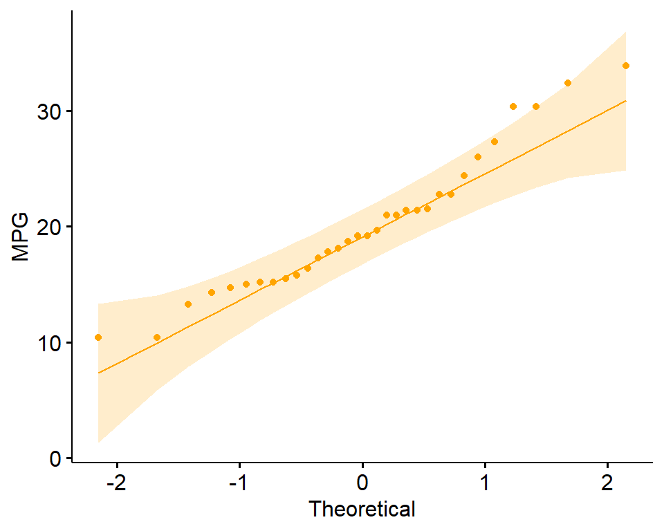

```r
library("ggpubr")

ggqqplot(my_data$mpg, ylab = "MPG", col = 'orange')   # for mpg variable
```

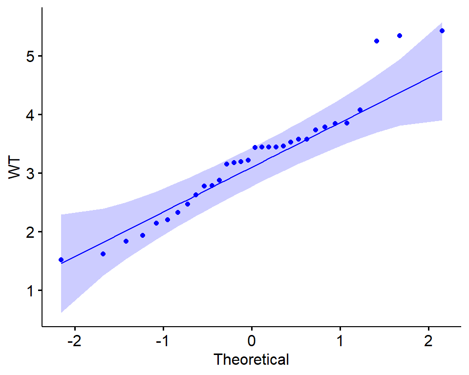

```r
ggqqplot(my_data$wt, ylab = "WT", col = 'blue')   # for wt variable
```

- From the normality plots, we conclude that both populations may come from normal distributions.
- **Note** that, if the data are not normally distributed, it’s recommended to use the **non-parametric** correlation, including `Spearman` and `Kendall` rank-based correlation tests.

### 12. Pearson correlation test

### 상관계수와 유의성까지 제공

- Correlation test between `mpg` and `wt` variables:

```r
( res <- cor.test(my_data$wt, my_data$mpg, method = "pearson") )
```

```
##
##  Pearson's product-moment correlation
##
## data:  my_data$wt and my_data$mpg
## t = -9.559, df = 30, p-value = 1.294e-10
## alternative hypothesis: true correlation is not equal to 0
## 95 percent confidence interval:
##  -0.9338264 -0.7440872
## sample estimates:
##        cor
## -0.8676594
```

- In the result above :
  - t : the t-test statistic value (t = -9.559),
  - df : the degrees of freedom (df = 30),
  - p-value : the significance level of the t-test (p-value = $1.29410^{-10}$).
  - conf.int : the confidence interval of the correlation coefficient at 95% (conf.int = [-0.9338, -0.7441]);
  - sample estimates : the correlation coefficient (correlation coefficient = -0.87).

### 13. Interpretation of the result

- The p-value of the test is $1.29410^{-10}$, which is less than the significance level alpha = 0.05.
- We can conclude that `wt` and `mpg` are significantly correlated with a correlation coefficient of -0.87 and p-value of $1.29410^{-10}$.

### 14. Access to the values returned by `cor.test{stats}` function

- The function `cor.test{stats}` returns a list containing the following components:
  - `p.value`: the p-value of the test
  - `estimate`: the correlation coefficient

```r
# Extract the p.value
res$p.value
```

```
## [1] 1.293959e-10
```

```r
# Extract the correlation coefficient
res$estimate
```

```
##        cor
## -0.8676594
```

### 15. Kendall rank correlation test

The Kendall rank correlation coefficient or Kendall’s tau statistic is used to estimate a rank-based measure of association. This test may be used if the data do not necessarily come from a **bivariate** normal distribution.

```r
( res2 <- cor.test(my_data$wt, my_data$mpg,  method="kendall") )
```

```
##
##  Kendall's rank correlation tau
##
## data:  my_data$wt and my_data$mpg
## z = -5.7981, p-value = 6.706e-09
## alternative hypothesis: true tau is not equal to 0
## sample estimates:
##        tau
## -0.7278321
```

- `tau` is the **Kendall** correlation coefficient.
- The correlation coefficient between x and y are -0.7278 and the p-value is $6.70610^{-9}$.

### 16. Spearman rank correlation coefficient

- Spearman’s rho statistic is also used to estimate a rank-based measure of association.
- This test may be used if the data do **not** come from a bivariate normal distribution.

```r
( res2 <-cor.test(my_data$wt, my_data$mpg,  method = "spearman") )
```

```
##
##  Spearman's rank correlation rho
##
## data:  my_data$wt and my_data$mpg
## S = 10292, p-value = 1.488e-11
## alternative hypothesis: true rho is not equal to 0
## sample estimates:
##       rho
## -0.886422
```

- `rho` is the Spearman’s correlation coefficient.
- The correlation coefficient between x and y are -0.8864 and the p-value is $1.48810^{-11}$.

### 18. Summary

- Use the function `cor.test(x,y)` to analyze the correlation coefficient between two variables and to get significance level of the correlation.
- Three possible correlation methods using the function `cor.test(x,y)`: **pearson**, **kendall**, **spearman**